# obAnalytics Guide

[Phil Nocturne](http://parasec.net)

2015-09-18

# Overview

*obAnalytics* is an R package intended for visualisation and analytics of limit order data.

This guide is structured as an end-to-end walk-through and is intended to demonstrate the main features and functionality of the package.

## Recommended environment settings

Due to the large number of columns in the example data, it is recommended to set the display width to make the most use of the display. It is also recommended to set *digits.secs=3* and *scipen=999* in order to display timestamps and fractions nicely. This can be achieved as follows:

```r
max.cols <- Sys.getenv("COLUMNS")
options(width=if(max.cols != "") max.cols else 80, scipen=999, digits.secs=3)
```

# Loading data

The main focus of this package is reconstruction of a limit order book. The *processData* function will perform data processing based on a supplied CSV file, the format of which is defined in the *Expected csv schema* section.

The data processing consists of a number of stages:

1. Cleaning of duplicate and erroneous data.
2. Identification of sequential event relationships.
3. Inference of trade events via order-matching.
4. Inference of order types (limit vs market).
5. Construction of volume by price level series.
6. Construction of order book summary statistics.

Limit order events are related to one another by volume deltas (the change in volume for a limit order). To simulate a matching-engine, and thus determine directional trade data, volume deltas from both sides of the limit order book are ordered by time, yielding a sequence alignment problem, to which the the Needleman-Wunsch algorithm has been applied.

```r
# load and process example csv data from the package inst/extdata directory.
csv.file <- system.file("extdata", "orders.csv.xz", package="obAnalytics")
lob.data <- processData(csv.file)
```

## Expected csv schema

The CSV file is expected to contain 7 columns:

Expected CSV schema.

| Column name | Description |
| --- | --- |
| **id** | Numeric limit order unique identifier. |
| **timestamp** | Time in milliseconds when event received locally. |
| **exchange.timestamp** | Time in milliseconds when order first created on the exchange. |
| **price** | Price level of order event. |
| **volume** | Remaining order volume. |
| **action** | Event action describes the limit order lifecycle. One of: **created**, **modified**, **deleted**. |
| **direction** | Side of order book. On of: **bid** or **ask**. |

## Preprocessed example data

For illustrative purposes, the package contains a sample of preprocessed data. The data, taken from the [Bitstamp](https://www.bitstamp.net/websocket) (bitcoin) exchange on 2015-05-01, consists of 50,393 limit order events and 482 trades occuring from midnight up until ~5am.

The sample data, which has been previously processed by the *processData* function, may be attached to the environment with the *data()* function:

```r
data(lob.data)
```

The *lob.data* object is a list containing four data.frames.

lob.data summary.

| data.frame | Summary |
| --- | --- |
| **events** | Limit order events. |
| **trades** | Inferred trades (executions). |
| **depth** | Order book price level depth through time. |
| **depth.summary** | Limit order book summary statistics. |

The contents of which are briefly discussed in the following sections.

### Events

The *events* data.frame contains the lifecycle of limit orders and makes up the core data of the obAnalytics package. Each row corresponds to a single limit order action, of which three types are possible.

Possible limit order actions.

[output not shown]

In addition to the event *action* type, a row consists of a number of attributes relating to the lifecycle of a limit order.

Limit order event attributes.

[output not shown]

An individual limit order (referenced by the *id* attribute) may be of six different types, all of which have been classified by onAnalytics.

Order types.

[output not shown]

The following table demonstrates a small snapshot (1 second) of event data. Some of the attributes have been omitted or renamed for readability.

```r
one.sec <- with(lob.data, {
  events[events$timestamp >= as.POSIXct("2015-05-01 04:55:10", tz="UTC") &
         events$timestamp <= as.POSIXct("2015-05-01 04:55:11", tz="UTC"),  ]
})
one.sec$volume <- one.sec$volume*10^-8
one.sec$fill <- one.sec$fill*10^-8
one.sec$aggressiveness.bps <- round(one.sec$aggressiveness.bps, 2)
one.sec <- one.sec[, c("event.id", "id", "price", "volume", "action",
    "direction", "fill", "matching.event", "type", "aggressiveness.bps")]
colnames(one.sec) <- c(c("event.id", "id", "price", "vol", "action", "dir",
    "fill", "match", "type", "agg"))
print(one.sec, row.names=F)
```

| event.id | id | price | vol | action | dir | fill | match | type | agg |
| --- | --- | --- | --- | --- | --- | --- | --- | --- | --- |
| 48258 | 65619043 | 235.84 | 0.000000 | deleted | ask | 1.6379919 | 49021 | market-limit | NA |
| 48443 | 65619136 | 235.98 | 0.000000 | deleted | ask | 0.2118824 | 49022 | resting-limit | -6.36 |
| 48617 | 65619223 | 237.12 | 20.762160 | deleted | ask | 0.0000000 | NA | flashed-limit | -47.03 |
| 48879 | 65619359 | 236.18 | 15.988592 | deleted | ask | 0.0000000 | NA | flashed-limit | -7.20 |
| 48997 | 65619419 | 235.83 | 0.000000 | deleted | ask | 1.8498742 | NA | unknown | NA |
| 49001 | 65619421 | 236.01 | 15.435748 | changed | ask | 6.6832516 | 49023 | resting-limit | NA |
| 49020 | 65619430 | 236.05 | 8.533126 | changed | bid | 1.8498742 | NA | market | NA |
| 49021 | 65619430 | 236.05 | 6.895134 | changed | bid | 1.6379919 | 48258 | market | NA |
| 49022 | 65619430 | 236.05 | 6.683252 | changed | bid | 0.2118824 | 48443 | market | NA |
| 49023 | 65619430 | 236.05 | 0.000000 | deleted | bid | 6.6832516 | 49001 | market | NA |
| 49024 | 65619431 | 235.06 | 13.200000 | created | bid | 0.0000000 | NA | resting-limit | -28.85 |
| 49027 | 65619432 | 236.03 | 13.200000 | created | ask | 0.0000000 | NA | flashed-limit | -0.85 |
| 49029 | 65619433 | 233.71 | 8.665815 | created | bid | 0.0000000 | NA | flashed-limit | -86.11 |
| 49030 | 65619433 | 233.71 | 8.665815 | deleted | bid | 0.0000000 | NA | flashed-limit | -86.11 |
| 49031 | 65619434 | 236.94 | 22.749000 | created | ask | 0.0000000 | NA | flashed-limit | -39.41 |

### Trades

The package automatically infers execution/trade events from the provided limit order data.

The trades data.frame contains a log of all executions ordered by local timestamp.

In addition to the usual timestamp, price and volume information, each row also contains the trade direction (buyer or seller initiated) and maker/taker limit order ids.

The maker/taker event and limit order ids can be used to group trades into market impacts - An example of which will be demonstrated later in this guide.

```r
trades.ex <- tail(lob.data$trades, 10)
trades.ex$volume <- round(trades.ex$volume*10^-8, 2)
print(trades.ex, row.names=F)
```

| timestamp | price | volume | direction | maker.event.id | taker.event.id | maker | taker |
| --- | --- | --- | --- | --- | --- | --- | --- |
| 2015-05-01 04:59:27.503 | 235.73 | 0.01 | buy | 49630 | 49777 | 65619731 | 65619806 |
| 2015-05-01 04:59:27.532 | 235.79 | 0.02 | buy | 49672 | 49778 | 65619752 | 65619806 |
| 2015-05-01 04:59:41.568 | 235.77 | 0.02 | buy | 49802 | 49821 | 65619818 | 65619826 |
| 2015-05-01 04:59:55.877 | 235.77 | 0.02 | buy | 49803 | 49871 | 65619818 | 65619851 |
| 2015-05-01 04:59:59.217 | 235.77 | 0.38 | buy | 49804 | 49877 | 65619818 | 65619854 |
| 2015-05-01 05:00:08.361 | 235.77 | 0.12 | sell | 49878 | 49894 | 65619854 | 65619862 |
| 2015-05-01 05:00:08.395 | 235.58 | 0.21 | sell | 49406 | 49895 | 65619615 | 65619862 |
| 2015-05-01 05:00:08.424 | 235.01 | 0.07 | sell | 46221 | 49896 | 65618028 | 65619862 |
| 2015-05-01 05:00:10.108 | 235.79 | 0.02 | buy | 49816 | 49900 | 65619824 | 65619864 |
| 2015-05-01 05:03:13.566 | 235.45 | 0.05 | sell | 49992 | 50255 | 65619912 | 65620048 |

Each row, representing a single trade, consists of the following attributes:

Trade data attributes.

| Attribte | Meaning |
| --- | --- |
| **timestamp** | Local event timestamp. |
| **price** | Price at which the trade occured. |
| **volume** | Amount of traded volume. |
| **direction** | The trade direction: *buy* or *sell*. |
| **maker.event.id** | Corresponding market making event id in *events* data.frame. |
| **taker.event.id** | Corresponding market taking event id in *events* data.frame. |
| **maker** | Id of the market making limit order in *events* data.frame. |
| **taker** | Id of the market taking limit order in *events* data.frame. |

### Depth

The depth data.frame describes the amount of available volume for all price levels in the limit order book through time. Each row corresponds to a limit order event, in which volume has been added or removed.

The data.frame represents a run-length-encoding of the cumulative sum of depth for all price levels and consists of the following attributes:

Depth attributes.

| Attribute | Meaning |
| --- | --- |
| **timestamp** | Time at which volume was added or removed. |
| **price** | Order book price level. |
| **volume** | Amount of remaining volume at this price level. |
| **side** | The side of the price level: bid or ask. |

### Depth summary

The depth.summary data.frame contains various summary statistics describing the state of the order book after every limit order event. The metrics are intended to quantify the shape of the order book through time.

Order book summary metrics.

| Attribute | Meaning |
| --- | --- |
| **timestamp** | Local timestamp corresponding to events. |
| **best.bid.price** | Best bid price. |
| **best.bid.vol** | Amount of volume available at the best bid. |
| **bid.vol25:500bps** | The amount of volume available for 20 25bps percentiles below the best bid. |
| **bid.vwap25:500bps** | The VWAP for 20 25bps percentiles below the best bid. |
| **best.ask.price** | The best ask price. |
| **best.ask.vol** | Amount of volume available at the best ask. |
| **ask.vol25:500bps** | The amount od volume available for 20 25bps percentiles above the best ask. |
| **ask.vwap25:500bps** | The VWAP for 20 25bps percentiles above the best ask. |

# Visualisation

The package provides a number of functions for the visualisation of limit order events and order book liquidity. The visualisations all make use of the ggplot2 plotting system.

## Order book shape

The purpose of the cumulative volume graph is to quickly identify the shape of the limit order book for the given point in time. The “shape” is defined as the cumulative volume available at each price level, starting at the best bid/ask.

Using this shape, it is possible to visually summarise order book imbalance and market depth.

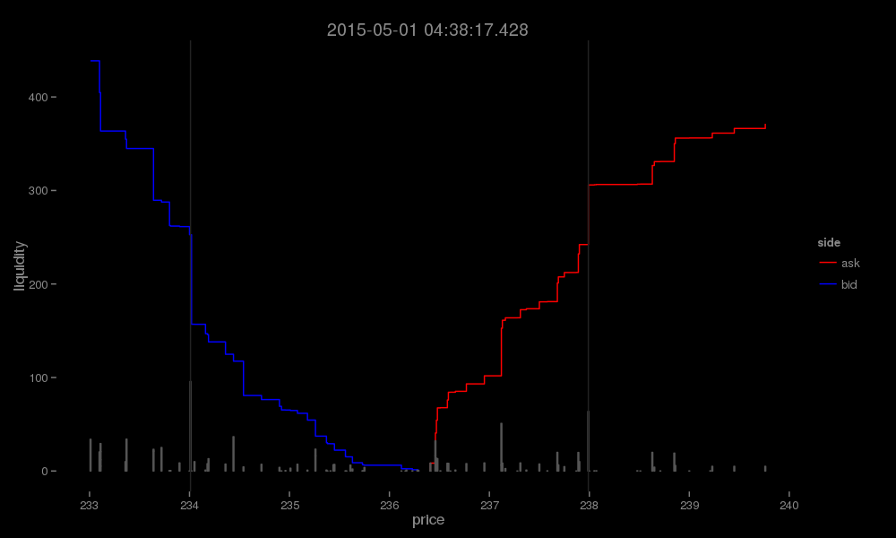

```r
# get a limit order book for a specific point in time, limited to +- 150bps
# above/below best bid/ask price.
lob <- orderBook(lob.data$events,
    tp=as.POSIXct("2015-05-01 04:38:17.429", tz="UTC"), bps.range=150)

# visualise the order book liquidity.
plotCurrentDepth(lob, volume.scale=10^-8)
```

In the figure above, an order book has been reconstructed with the *orderBook* function for a specific point in time. The visualisation produced with the *plotCurrentDepth* function depicts a number of order book features. Firstly, the embedded bar chart at the bottom of the plot shows the amount of volume available at specific price levels ranging from the *bid* side on the left (blue) through to the *ask* side (red) on the right. Secondly, the blue and red lines show the *cumulative* volume of the bar chart for the bid and ask sides of the order book respectively. Finally, the two subtle vertical lines at price points $234 and $238 show the position of the top 1% largest limit orders.